# FX_Trading

1. Suggest one data source that might be useful to explain or predict the FX market.
2. Derive and discuss relevant analytics from this data source.
3. Determine whether your proposed analytics are co-integrated with currency pairs.
4. Describe and implement a pairs trading strategy exploiting your analytics.

#### Import libraries

```r
library(xts)
library(Quandl)
library(lubridate)
library(tseries)
Quandl.api_key("M2-Rpsxfj4vXk5_22GAV")
```

#### PREDICTOR 1: OIL PRICE

Economies that are heavily reliant on oil exports see large swings in their currency’s value driven by the price of oil. With this hypotheis, it may be argued that the currency of Norway, Krone, could be predicted using the oil price. Following link has info on countries most dependent on oil. # https://www.weforum.org/agenda/2016/05/which-economies-are-most-reliant-on-oil/

#### PREDICTOR 2: INTEREST RATE DIFFERENTIAL

Due to carry traders, in the short to medium term, currencies with higher interest rates tend to get stronger given investor interest.

#### RESPONSE VARIABLE: NORWEGIAN KRONE FX RATE

```r
usdInKrones <- Quandl('FRED/DEXNOUS')
usdInKrones <- xts(usdInKrones$Value, usdInKrones$Date)
usdInKrones <- apply.monthly(usdInKrones, last)
index(usdInKrones) <- as.yearmon(index(usdInKrones))
head(usdInKrones)
```

```
##            [,1]
## Jan 1971 7.1445
## Feb 1971 7.1420
## Mar 1971 7.1314
## Apr 1971 7.1312
## May 1971 7.1115
## Jun 1971 7.1048
```

### PREDICTOR 1: OIL PRICE

```r
oil_quandl <- Quandl('CHRIS/ICE_B1')
oil_continuous <- xts(oil_quandl$Settle, oil_quandl$Date)
oil_price_monthly<-apply.monthly(oil_continuous, last)
index(oil_price_monthly) <- as.yearmon(index(oil_price_monthly))
head(oil_price_monthly)
```

```
##           [,1]
## Mar 1993 19.00
## Apr 1993 19.24
## May 1993 19.02
## Jun 1993 18.32
## Jul 1993 17.25
## Aug 1993 17.85
```

### PREDICTOR 2: INTEREST RATE DIFFERENTIAL

```r
norway_rates_df <- read.csv('https://www.norges-bank.no/globalassets/marketdata/stat/en/renter/v2/renter_mnd.csv')
dates<-dmy(paste0('01-',as.character(norway_rates_df$DATES)))
norway_rates <- xts(norway_rates_df[,2:ncol(norway_rates_df)], order.by=dates)
norway_rf <- norway_rates$STATSVKL.3M.EFF
norway_rf <- norway_rf[norway_rf[,1]!="ND"]
norway_rf <- xts(as.numeric(norway_rf), index(norway_rf))
index(norway_rf) <- as.yearmon(index(norway_rf))
month_end_norway_rf <- apply.monthly(norway_rf, last)
index(month_end_norway_rf) <- as.yearmon(index(month_end_norway_rf))

us_rates <- Quandl('FRED/TB3MS')
us_rates <- xts(us_rates$Value, order.by=us_rates$Date)
month_end_us_rf <- apply.monthly(us_rates, last)
index(month_end_us_rf) <- as.yearmon(index(month_end_us_rf))

IRD <- month_end_us_rf - month_end_norway_rf
names(IRD) <- "IRD"
```

### We expect a positive coeff to IRD and neg coeff to oil price

```r
data_fx2 <- na.trim(merge(merge(usdInKrones, oil_price_monthly), IRD))
model <- lm(usdInKrones ~  oil_price_monthly + IRD, data=data_fx2)
summary(model)
```

```
##
## Call:
## lm(formula = usdInKrones ~ oil_price_monthly + IRD, data = data_fx2)
##
## Residuals:
##      Min       1Q   Median       3Q      Max
## -1.36824 -0.56951 -0.08303  0.36650  1.57303
##
## Coefficients:
##                    Estimate Std. Error t value Pr(>|t|)
## (Intercept)        8.337439   0.141536  58.907   <2e-16 ***
## oil_price_monthly -0.022832   0.001896 -12.045   <2e-16 ***
## IRD                0.082833   0.035313   2.346   0.0201 *
## ---
## Signif. codes:  0 '***' 0.001 '**' 0.01 '*' 0.05 '.' 0.1 ' ' 1
##
## Residual standard error: 0.6933 on 178 degrees of freedom
## Multiple R-squared:  0.5087, Adjusted R-squared:  0.5031
## F-statistic: 92.14 on 2 and 178 DF,  p-value: < 2.2e-16
```

#### The signs of model coefficients are in line with our expectation

### Diagnostics

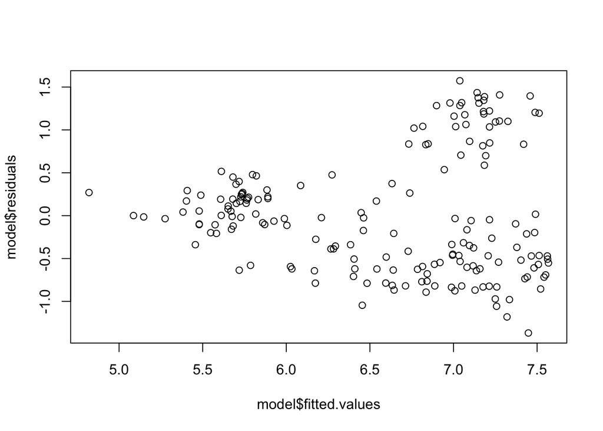

```r
plot(model$fitted.values, model$residuals)
```

The residuals vs fitted values chart indicates greater vol for residuals for bigger fitted values (log transform may help the model - but will render it untradable). Check if the residuals are stationary:

```r
adf.test(model$residuals) # as expected, residuals don't show strong evidence for stationarity
```

```
##
##  Augmented Dickey-Fuller Test
##
## data:  model$residuals
## Dickey-Fuller = -3.3044, Lag order = 5, p-value = 0.07249
## alternative hypothesis: stationary
```

Since the residuals are hardly stationary, the regression does not define a cointegrated combination of the predictors with the fx rate. Therefore, we do not have a strong case for pairs trading.

### Implementing pairs trading using (FX_return ~ Oil_price + Interest_rate_differential) model

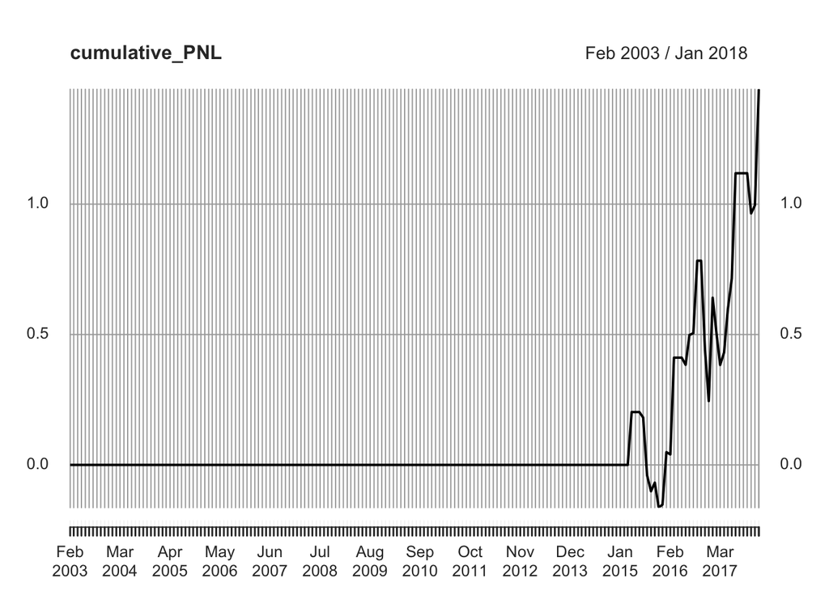

```r
coeff <- model$coefficients
#  wts as obtained as per regression above
# USD/Krone = Buy 1 contract
# Oil futures = Buy -coeff[1] contracts
# USTsy-NorwayTsyRrate = Buy -coeff[2] contracts, where buying 1 contract means = Buy 1 ITM US tsy 3-mo cap, sell 1 ITM Norway 3mo cap
cointegrated_wts <- c(1, -coeff[2], -coeff[3])
# These wts correspond to unit long position in the stationary process obtained from regression.
# Buying in these proportions will signify a bet on the mean-reversion of the stationary residual

SD <-sd(model$residuals)
intercept <- coeff[1]
zero_weights <- c(0, 0, 0)
wts<-list()
wts[[1]] <- zero_weights
current_position = 'no'

for (i in 1:nrow(data_fx2)) {

     stationary_process_value <- sum(data_fx2[i,] * cointegrated_wts) - intercept

     if(current_position == 'no') {
     if(stationary_process_value > 1.5*SD & stationary_process_value <= 2.5*SD){
       # go short the stationary process
       wts[[i]] = -1 * cointegrated_wts
       current_position = 'short'
     }
     if(stationary_process_value < -1.5*SD & stationary_process_value >= -2.5*SD){
       # go long the stationary process
       wts[[i]] = cointegrated_wts
       current_position = 'long'
     }
     if(stationary_process_value <= 1.5*SD & stationary_process_value >= -1.5*SD) {
       # do nothing
       wts[[i]]= zero_weights
     }
     if(stationary_process_value > 2.5*SD | stationary_process_value < -2.5*SD){
       # do nothing
       wts[[i]] = zero_weights
     }
     }


     if(current_position == 'short') {
       if(stationary_process_value <= 0.3*SD & stationary_process_value >= -1.5*SD ){
         # close the position
         wts[[i]] <- zero_weights
         current_position = 'no'
       }
       if(stationary_process_value < -1.5*SD & stationary_process_value > -2.5*SD){
         # close the position and
         # go long the stationary process
         wts[[i]] <- cointegrated_wts
         current_position = 'long'
       }
       if(stationary_process_value > 2.5*SD){
         # close the position - cut your losses
         wts[[i]] <- zero_weights
         current_position = 'no'
       }
       if(stationary_process_value < -2.5*SD){
         # close the position - something strange is going on so don't initiate a long position
         wts[[i]] <- zero_weights
         current_position = 'no'
       }
       if(stationary_process_value <= 2.5*SD & stationary_process_value > 0.3*SD){
         # continue as before
         wts[[i]] <- wts[[i-1]]

       }
     }



     if(current_position == 'long') {
       if(stationary_process_value >= -0.3*SD & stationary_process_value <= 1.5*SD ){
         # close the position
         wts[[i]] <- zero_weights
       }
       if(stationary_process_value > 1.5*SD & stationary_process_value <= 2.5*SD){
         # close the position
         # go short the stationary process
         wts[[i]] <- -1*cointegrated_wts
       }
       if(stationary_process_value < -2.5*SD){
         # close the position - cut your losses
         wts[[i]] <- zero_weights
       }
       if(stationary_process_value > 2.5*SD){
         # close the position - something strange is going on so don't initiate a short position
         wts[[i]] <- zero_weights
       }
       if(stationary_process_value >= -2.5*SD & stationary_process_value < -0.3*SD){
         # continue as before
         wts[[i]] <- wts[[i-1]]
       }
     }



  }

weights <- do.call(rbind, wts)
price_moves <- na.trim(diff(data_fx2))
PNL_contribs <- head(weights, -1) * coredata(price_moves)
PNL_contribs <- xts(PNL_contribs, order.by=index(price_moves))
PNL <- apply(PNL_contribs, 1, sum)
PNL <- xts(PNL, index(price_moves))
cumulative_PNL <- cumsum(PNL)
plot(cumulative_PNL)
```

### Thoughts on cons and possible improvement

1. Regression did not provide strong evidence for cointegration, but I went ahead and implemented the pairs trading strategy assuming as if there was reasonable evidence.
2. The strategy suffers from look-ahead bias, since I already used the whole period to identify cointegrating weights, and then implemented the strategy from the beginning of that entire period. This can be improved in 2 ways:
1. Use the first half of the time series data just to estimate the cointegrating weights, and the second half to run the pairs trading strategy test.
2. Use expanding window, such that all the time series data up to that point is used to determine the cointegrating vector.
3. Using the johannsen or the granger-engle method instead of linear regression could have identified certain cointegrating vectors not identified by regression, which may have been better cointegrating vectors too, given that the cointegrating vector I found from regression wasn’t very robust (the regression residual did not show strong evidence for stationarity).